```r
library(binom)
library(car)
library(collapsibleTree)
library(dbplyr)
library(dplyr)
library(EnvStats)
library(ggformula)
```

```r
library(ggplot2)
library(gmodels)
library(htmltools)
library(ISLR)
library(knitr)
library(lawstat)
library(markdown)
library(mosaic)
library(mdsr)
library(mosaicData)
library(nycflights13)
library(olsrr)
library(plyr)
library(purrr)
library(plotly)
library(resampledata)
library(rmarkdown)
library(rpart)
library(rpart.plot)
library(rvest)
library(SDaA)
library(shiny)
library(stringi)
library(tibble)
library(tidyr)
library(tidyselect)
library(tinytex)
library(yaml)
library(shiny)
```

##Q1

**Q1 a**

The statistical hypothesis to be tested is

$$\begin{eqnarray}
{\rm H}_{0}: \mu_{vitC} & = & \mu_{Placebo} \hspace{0.2in}
\text{(The differences between the two sample means of recovery time are
the result of randomness)} \\
{\rm H}_{A}: \mu_{vitC} & < & \mu_{Placebo} \text{(The
recovery time is quicker with Vitamin C than without)} \\
\end{eqnarray}$$
If the Vitamin C is more effective,in another words,the recovery time is quicker with Vitamin C than without, then the
$$\mu_{vitC} < \mu_{Placebo} \longrightarrow \mu_{vitC} - \mu_{Placebo}
< 0$$

I set up the $\alpha = 0.05$

```r
VitC = c(6, 7, 7, 7, 8, 7, 7, 8, 7, 8, 10, 6, 8, 5, 6)
Placebo = c(10, 12, 8, 6, 9, 8, 11, 9, 11, 8, 12, 11, 9, 8, 10, 9)
recovertime = c(Placebo, VitC)
isVitC = c(rep("Placebo", 16),rep("VitC", 15) )
recoverdata = data.frame(isVitC, recovertime)
head(recoverdata, 4)
```

```
##    isVitC recovertime
## 1 Placebo          10
## 2 Placebo          12
## 3 Placebo           8
## 4 Placebo           6
```

```r
tail(recoverdata,4)
```

```
##    isVitC recovertime
## 28   VitC           6
## 29   VitC           8
## 30   VitC           5
## 31   VitC           6
```

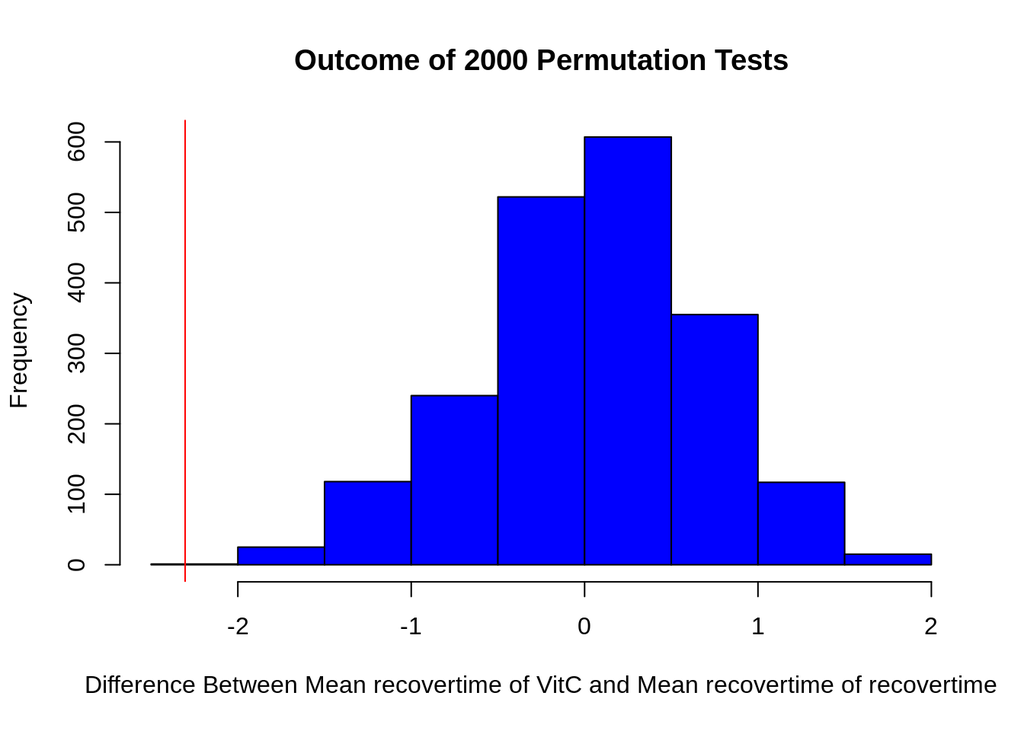

```r
obsdiff = mean(~recovertime, data=filter(recoverdata, isVitC=="VitC"))  - mean(~recovertime, data=filter(recoverdata, isVitC=="Placebo"))
outcome = numeric(2000) #create a vector to store differences of means
for(i in 1:2000)
{ index = sample(31, 15, replace=FALSE)
  outcome[i] = mean(recoverdata$recovertime[index]) - mean(recoverdata$recovertime[-index]) #difference between means
}
hist(outcome, xlab="Difference Between Mean recovertime of VitC and Mean recovertime of recovertime", ylab="Frequency", main="Outcome of 2000 Permutation Tests", col='blue')
abline(v = obsdiff, col="red")
```

```r
pvalueq1 = (sum(outcome < obsdiff))/(2000)  #computes P-value
pvalueq1
```

```
## [1] 0
```

Because $p-value < \alpha$, Reject $H_{0}: \mu_{vitC} & = & \mu_{Placebo}$. I conclude that the recovery time is quicker with Vitamin C than without.

**Q1 b**

```r
#t-test
t.test(VitC,Placebo, conf.level=0.95, alternative="less", data=recoverdata)
```

```
##
##  Welch Two Sample t-test
##
## data:  VitC and Placebo
## t = -4.445, df = 27.08, p-value = 6.723e-05
## alternative hypothesis: true difference in means is less than 0
## 95 percent confidence interval:
##       -Inf -1.421325
## sample estimates:
## mean of x mean of y
##  7.133333  9.437500
```

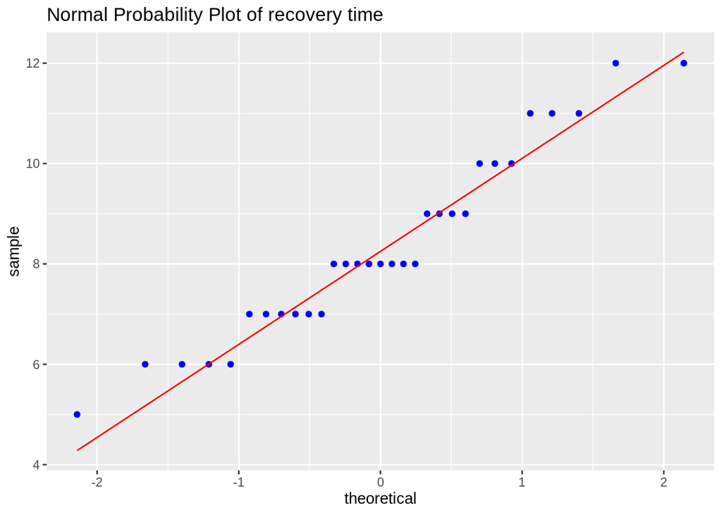

```r
ggplot(recoverdata, aes(sample = recovertime)) + stat_qq(col="blue") + stat_qqline(col="red") + ggtitle("Normal Probability Plot of recovery time")
```

##Q2

**a**

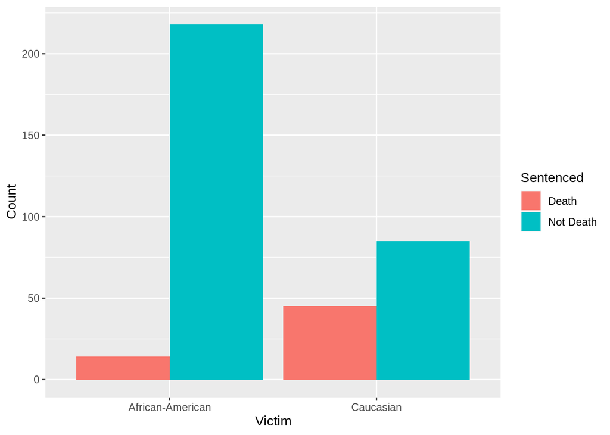

```r
df <- data.frame(Sentenced = c("Death", "Not Death", "Death", "Not Death"),
                 Count = c(45, 85, 14, 218),
                 Victim = c("Caucasian"   ,  "Caucasian" ,  "African-American" ,  "African-American")
                 )
ggplot(data=df, aes(Victim,Count, fill=Sentenced)) + geom_bar(position = "dodge",stat = "identity")
```

**b** The statistical hypothesis to be tested is

$$\begin{eqnarray}
{\rm H}_{0}: \text{the race of the victim does Not appear to affect
whether an African-American convicted of murder in Georgia will receive
a death sentence} \\
{\rm H}_{A}: \text{the race of the victim does appear to affect whether
an African-American convicted of murder in Georgia will receive a death
sentence} \\
\end{eqnarray}$$
I set up the $\alpha = 0.05$

```r
death = rbind(c(45,85), c(14, 218))
rownames(death) = c("Victim was Caucasian", "Victim was African-American")
colnames(death) = c("Sentenced to Death", "Not Sentenced to Death")
death
```

```
##                             Sentenced to Death Not Sentenced to Death
## Victim was Caucasian                        45                     85
## Victim was African-American                 14                    218
```

```r
chisq.test(death, correct=FALSE)
```

```
##
##  Pearson's Chi-squared test
##
## data:  death
## X-squared = 49.888, df = 1, p-value = 1.628e-12
```

```r
pvalue = 1.628e-12
pvalue
```

```
## [1] 1.628e-12
```

Because $p-value < \alpha$, Reject $H_{0}$. I conclude that the race of the victim does appear to affect whether an African-American convicted of murder in Georgia will receive a death sentence.

The confidence interval:

```r
prop.test(c(45,14), c(45+85,14+218), alternative="two.sided", correct=FALSE)
```

```
##
##  2-sample test for equality of proportions without continuity
##  correction
##
## data:  c out of c45 out of 45 + 8514 out of 14 + 218
## X-squared = 49.888, df = 1, p-value = 1.628e-12
## alternative hypothesis: two.sided
## 95 percent confidence interval:
##  0.1984768 0.3731412
## sample estimates:
##     prop 1     prop 2
## 0.34615385 0.06034483
```

The 95 percent confidence interval is: (0.1984768, 0.3731412)

## Q3

**a**

```r
df.q3 = read.csv("http://people.ucalgary.ca/~jbstall/DataFiles/CloudSeedingData.csv")
head(df.q3)
```

```
##   RAINFALL TREATMENT
## 1   1202.6  UNSEEDED
## 2    830.1  UNSEEDED
## 3    372.4  UNSEEDED
## 4    345.5  UNSEEDED
## 5    321.2  UNSEEDED
## 6    244.3  UNSEEDED
```

```r
tail(df.q3)
```

```
##    RAINFALL TREATMENT
## 47     40.6    SEEDED
## 48     32.7    SEEDED
## 49     31.4    SEEDED
## 50     17.5    SEEDED
## 51      7.7    SEEDED
## 52      4.1    SEEDED
```

$$\hspace{0.25in} {\rm H}_{0}: \mu_{seeded} - \mu_{unseeded} = 0
\hspace{0.25in} \text{(cloud seeding does not have an effect on rainfall
on average)}
\\
\hspace{0.25in} {\rm H}_{A}: \mu_{seeded} - \mu_{unseeded} \ne 0
\hspace{0.25in} \text{(cloud seeding does have an effect on rainfall on
average)}$$
I set up the $\alpha = 0.05$

```r
t.test(~RAINFALL|TREATMENT, conf.level=0.95, alternative = "two.sided", var.equal=FALSE, df.q3)
```

```
##
##  Welch Two Sample t-test
##
## data:  RAINFALL by TREATMENT
## t = 1.9982, df = 33.855, p-value = 0.05377
## alternative hypothesis: true difference in means between group SEEDED and group UNSEEDED is not equal to 0
## 95 percent confidence interval:
##   -4.764295 559.556603
## sample estimates:
##   mean in group SEEDED mean in group UNSEEDED
##               441.9846               164.5885
```

Because $p-value > \alpha$, Fail to Reject $H_{0}$. I conclude that, on average, cloud seeding does not have an effect on rainfall. The 95 percent confidence interval is: (-4.764295, 559.556603)

```r
n.SEEDED = favstats(~RAINFALL|TREATMENT, data=df.q3)$n[1]
n.UNSEEDED = favstats(~RAINFALL|TREATMENT, data=df.q3)$n[2]
n.SEEDED
```

```
## [1] 26
```

```r
n.UNSEEDED
```

```
## [1] 26
```

```r
#n > 25
#Condition satisfied
```

**b**
$$\hspace{0.25in} {\rm H}_{0}: \frac{\sigma_{seeded}}{\sigma_{unseeded}}
\ge 1 \hspace{0.25in}
\\
\hspace{0.25in} {\rm H}_{A}: \frac{\sigma_{seeded}}{\sigma_{unseeded}}
< 1$$
I set up the $\alpha = 0.05$

```r
favstats(~RAINFALL|TREATMENT, data=df.q3)
```

```
##   TREATMENT min     Q1 median      Q3    max     mean       sd  n missing
## 1    SEEDED 4.1 98.125  221.6 406.025 2745.6 441.9846 650.7872 26       0
## 2  UNSEEDED 1.0 24.825   44.2 159.200 1202.6 164.5885 278.4264 26       0
```

```r
favstats(~RAINFALL|TREATMENT, data=df.q3)$sd[2]
```

```
## [1] 278.4264
```

```r
favstats(~RAINFALL|TREATMENT, data=df.q3)$sd[1] / favstats(~RAINFALL|TREATMENT, data=df.q3)$sd[2]
```

```
## [1] 2.337376
```

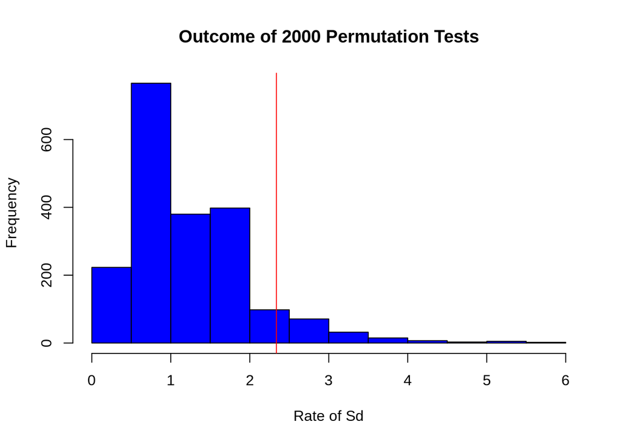

```r
sd.obs = favstats(~RAINFALL|TREATMENT, data=df.q3)$sd[1] / favstats(~RAINFALL|TREATMENT, data=df.q3)$sd[2]

outcome = numeric(2000) #create a vector to store rate of sd
for(i in 1:2000)
{ index = sample(52, 26, replace=FALSE)
  outcome[i] = sd(df.q3$RAINFALL[index]) / sd(df.q3$RAINFALL[-index])
}
hist(outcome, xlab="Rate of Sd", ylab="Frequency", main="Outcome of 2000 Permutation Tests", col='blue')
abline(v = sd.obs, col="red")
```

```r
pvalueq3b = (sum(outcome <= sd.obs) )/(2000)  #computes P-value
pvalueq3b
```

```
## [1] 0.922
```

Because $p-value > \alpha$, Fail to Reject $H_{0}$.

**c**

```r
df.q3 = df.q3 %>%
  mutate(Ln = log(RAINFALL)) #create a new variable called Diff = price of camera at JR - price of same camera at BH
head(df.q3)
```

```
##   RAINFALL TREATMENT       Ln
## 1   1202.6  UNSEEDED 7.092241
## 2    830.1  UNSEEDED 6.721546
## 3    372.4  UNSEEDED 5.919969
## 4    345.5  UNSEEDED 5.844993
## 5    321.2  UNSEEDED 5.772064
## 6    244.3  UNSEEDED 5.498397
```

$$\hspace{0.25in} {\rm H}_{0}: \overline{ln(X_{SEEDED})} -
\widetilde{ln(X_{UNSEEDED})} = 0 \hspace{0.25in}
\\
\hspace{0.25in} {\rm H}_{A}: \overline{ln(X_{SEEDED})} -
\widetilde{ln(X_{UNSEEDED})} \neq 0 \hspace{0.25in}$$
I set up the $\alpha = 0.05$

```r
favstats(~RAINFALL|TREATMENT, data=df.q3)
```

```
##   TREATMENT min     Q1 median      Q3    max     mean       sd  n missing
## 1    SEEDED 4.1 98.125  221.6 406.025 2745.6 441.9846 650.7872 26       0
## 2  UNSEEDED 1.0 24.825   44.2 159.200 1202.6 164.5885 278.4264 26       0
```

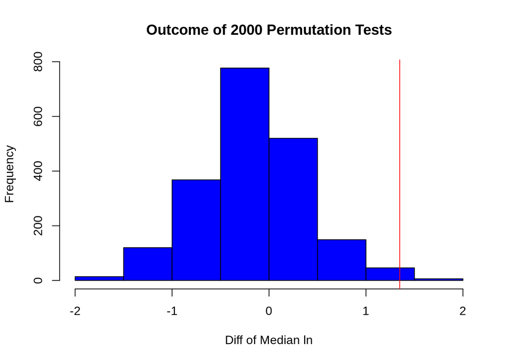

```r
diffmd.obs = favstats(~Ln|TREATMENT, data=df.q3)$mean[1] - favstats(~Ln|TREATMENT, data=df.q3)$median[2]

outcome3c = numeric(2000) #create a vector to store
for(i in 1:2000)
{ index = sample(52, 26, replace=FALSE)
  outcome3c[i] = mean(df.q3$Ln[index]) - median(df.q3$Ln[-index])
}
hist(outcome3c, xlab="Diff of Median ln", ylab="Frequency", main="Outcome of 2000 Permutation Tests", col='blue')
abline(v = diffmd.obs, col="red")
```

```r
pvalueq3 = (sum(outcome3c >= diffmd.obs) + sum(outcome3c <=  -diffmd.obs))/(2000)  #computes P-value
pvalueq3
```

```
## [1] 0.0225
```

Because $p-value < \alpha$,Reject $H_{0}$.

```r
favstats(outcome3c)
```

```
##        min         Q1     median        Q3      max       mean        sd    n
##  -1.796418 -0.5008519 -0.1704373 0.1564766 1.650685 -0.1632998 0.5487943 2000
##  missing
##        0
```

```r
diffmd.obs
```

```
## [1] 1.347928
```

##Q4

The statistical hypothesis to be tested is

$$\begin{eqnarray}
p_{minoxidil} > p_{Placebo} \longrightarrow p_{minoxidil} -
p_{Placebo} > 0
\end{eqnarray}$$

I set up the $\alpha = 0.05$

```r
prop.test(c(99,62), c(310,309), alternative="greater", correct=FALSE)
```

```
##
##  2-sample test for equality of proportions without continuity
##  correction
##
## data:  c out of c99 out of 31062 out of 309
## X-squared = 11.331, df = 1, p-value = 0.0003811
## alternative hypothesis: greater
## 95 percent confidence interval:
##  0.06124968 1.00000000
## sample estimates:
##    prop 1    prop 2
## 0.3193548 0.2006472
```

Because $p-value < \alpha$, Reject $H_{0}:p_{minoxidil} \le p_{placebo}$. I conclude that minoxidil is effective in treating male pattern baldness.

95 percent confidence interval is from 0.06124968 to 1.

## Q5

**a**

```r
df.q5 = read.csv("http://people.ucalgary.ca/~jbstall/DataFiles/chocnochocratings.csv")
#df.q5
```

Treatment effect means that student who got chocolate rate prof. higher than student who did not receive chocolate.

The statistical hypothesis to be tested is

$$\begin{eqnarray}
{\rm H}_{0}: \mu_{ChocolateQ9} & \leq & \mu_{NOChocQ9}
\hspace{0.2in} \text{(there is not a treatment effect)} \\
{\rm H}_{A}: \mu_{ChocolateQ9} & > & \mu_{NOChocQ9}
\hspace{0.2in} \text{(there is a treatment effect)} \\
\end{eqnarray}$$
If Treatment effect is true then:
$$\mu_{ChocolateQ9} > \mu_{NOChocQ9} \longrightarrow \mu_{ChocolateQ9}
- \mu_{NOChocQ9} > 0$$

I set up the $\alpha = 0.05$

```r
favstats(~Q9|GroupName, data=df.q5)
```

```
##   GroupName min Q1 median Q3 max     mean        sd  n missing
## 1 Chocolate   2  3      4  5   5 4.120000 0.9178502 50       0
## 2    NOChoc   1  3      4  5   5 3.916667 0.9186793 48       0
```

```r
favstats(~Q9|GroupName, data=df.q5)$mean[1]
```

```
## [1] 4.12
```

```r
favstats(~Q9|GroupName, data=df.q5)$mean[2]
```

```
## [1] 3.916667
```

```r
favstats(~Q9|GroupName, data=df.q5)$n[1]
```

```
## [1] 50
```

```r
favstats(~Q9|GroupName, data=df.q5)$n[2]
```

```
## [1] 48
```

```r
n = favstats(~Q9|GroupName, data=df.q5)$n[1] + favstats(~Q9|GroupName, data=df.q5)$n[2]
n
```

```
## [1] 98
```

```r
#1 cho
#2 nocho
```

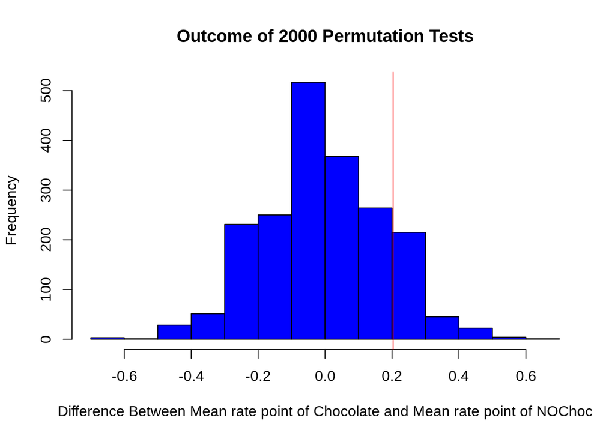

```r
obsdiff5 = favstats(~Q9|GroupName, data=df.q5)$mean[1] - favstats(~Q9|GroupName, data=df.q5)$mean[2]
N =2000
outcome5 = numeric(N)
for (i in 1:N){
  index = sample(98, 50, replace = FALSE)
  outcome5[i] = mean(df.q5$Q9[index]) - mean(df.q5$Q9[-index])
}

hist(outcome5, xlab="Difference Between Mean rate point of Chocolate and Mean rate point of NOChoc", ylab="Frequency", main="Outcome of 2000 Permutation Tests", col='blue')
abline(v = obsdiff5, col="red")
```

```r
pvalueq5 = (sum(outcome5 >= obsdiff5))/(N)  #computes P-value
pvalueq5
```

```
## [1] 0.1435
```

Because $p-value > \alpha$, Fail to Reject $H_{0}$. I conclude that there is not a treatment effect which means that student who got chocolate did not rate prof. higher than student who did not receive chocolate in Q9 on average.

**b** The statistical hypothesis to be tested is

$$\begin{eqnarray}
{\rm H}_{0}: \mu_{ChocolateOverall} & \leq &
\mu_{NOChocOverall} \hspace{0.2in} \text{(there is not a treatment
effect)} \\
{\rm H}_{A}: \mu_{ChocolateOverall} & > &
\mu_{NOChocOverall} \hspace{0.2in} \text{(there is a treatment effect)}
\\
\end{eqnarray}$$

$n > 25$ Condition satisfied I set up the $\alpha = 0.05$

```r
t.test(~Overall|GroupName, alternative = "greater", conf.level=0.95, var.equal=FALSE, df.q5)
```

```
##
##  Welch Two Sample t-test
##
## data:  Overall by GroupName
## t = 1.6616, df = 95.93, p-value = 0.04993
## alternative hypothesis: true difference in means between group Chocolate and group NOChoc is greater than 0
## 95 percent confidence interval:
##  9.400666e-05          Inf
## sample estimates:
## mean in group Chocolate    mean in group NOChoc
##                4.072000                3.849792
```

Because $p-value < \alpha$, Reject $H_{0}$.

**c**

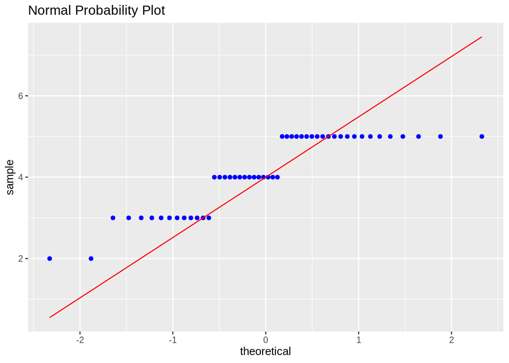

```r
ggplot(filter(df.q5, GroupName =="Chocolate"), aes(sample = Q9)) + stat_qq(col="blue") + stat_qqline(col="red") + ggtitle("Normal Probability Plot")
```

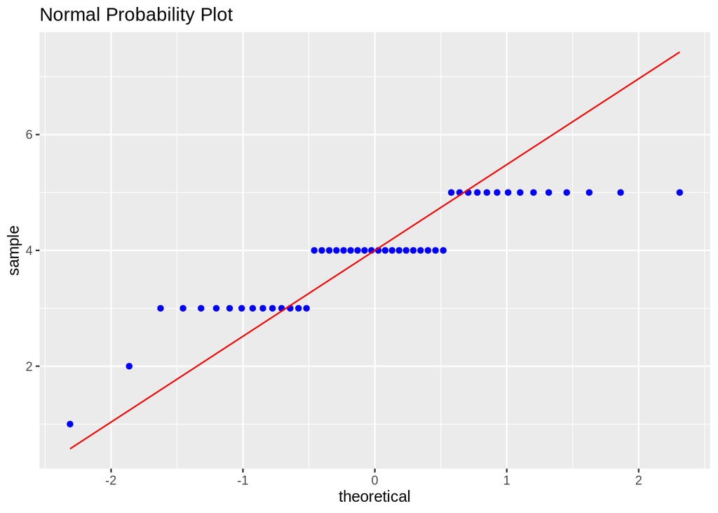

```r
ggplot(filter(df.q5, GroupName =="NOChoc"), aes(sample = Q9)) + stat_qq(col="blue") + stat_qqline(col="red") + ggtitle("Normal Probability Plot")
```

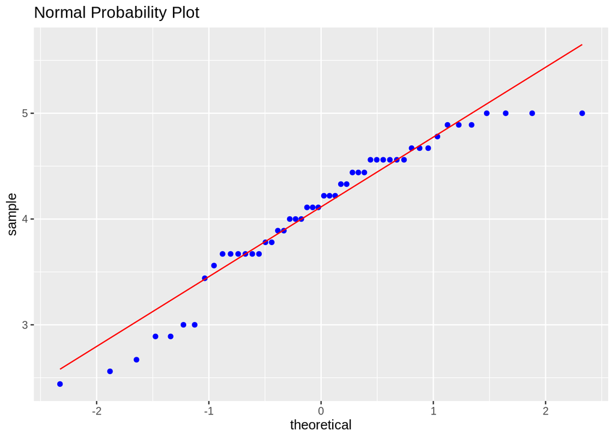

```r
ggplot(filter(df.q5, GroupName =="Chocolate"), aes(sample = Overall)) + stat_qq(col="blue") + stat_qqline(col="red") + ggtitle("Normal Probability Plot")
```

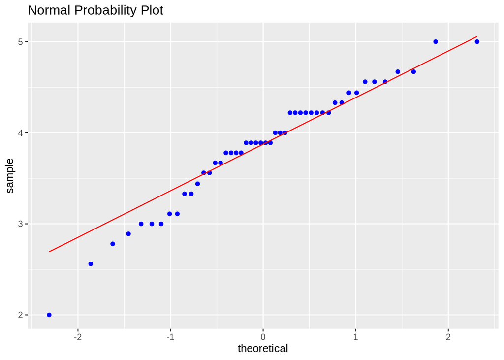

```r
ggplot(filter(df.q5, GroupName =="NOChoc"), aes(sample = Overall)) + stat_qq(col="blue") + stat_qqline(col="red") + ggtitle("Normal Probability Plot")
```

t-test not be a recommended statistical method to carry out the test in part (a) because The data is not normal.

##Q6

The statistical hypothesis to be tested is:

$$\begin{eqnarray}
{\rm H}_{0}: p_{agree \_2020} & \leq & p_{agree \_2018}
\hspace{0.2in} \text{( the proportion of Alberta residents who support
the Alberta’s adoption of a sales tax has no increased since March
2018)} \\
{\rm H}_{A}: p_{agree \_2020} & > & p_{agree \_2018}
\hspace{0.2in} \text{( the proportion of Alberta residents who support
the Alberta’s adoption of a sales tax has increased since March 2018)}
\\
\end{eqnarray}$$

I set up the $\alpha = 0.05$

```r
n20 = 900
x20 = 358
n18 = 900
x18 = 225
x = x20 + x18
n = n20 + n18
obsdiff6 =x20/n20 - x18/n18

obsdiff6
```

```
## [1] 0.1477778
```

```r
data=c(rep(1,x),rep(0,n - x))

N = 2000
outcome6 = numeric(N)
for(i in 1:N)
{ index = sample(n, n20, replace=FALSE)
  outcome6[i] = mean(data[index]) - mean(data[-index])
}
```

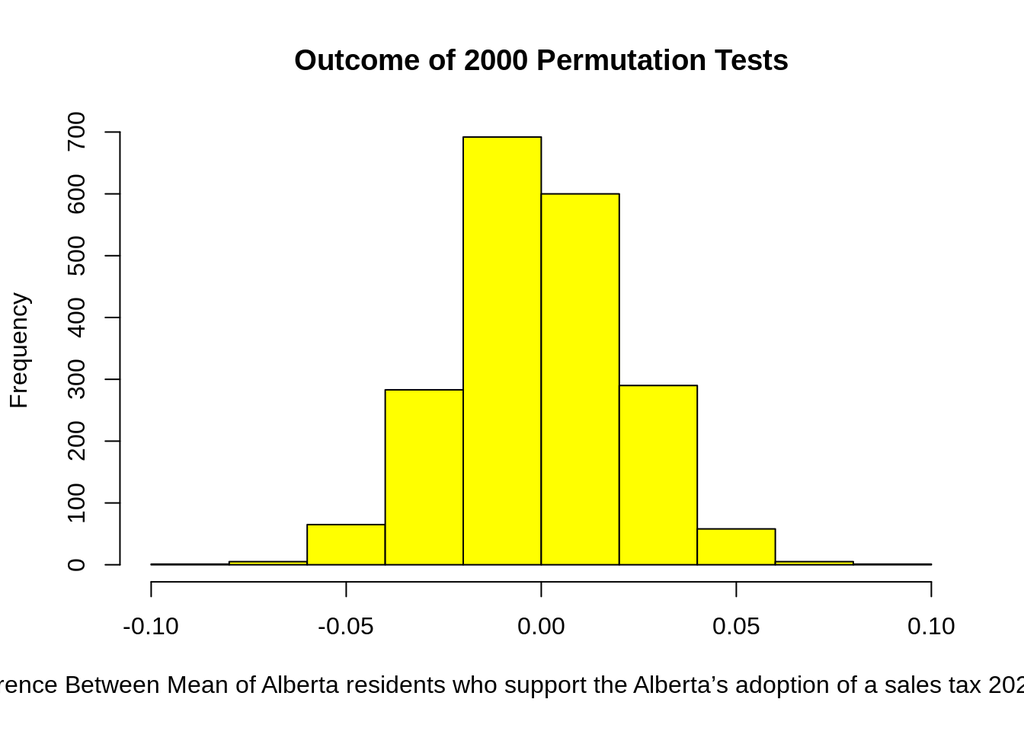

```r
hist(outcome6, xlab="Difference Between Mean of Alberta residents who support the Alberta’s adoption of a sales tax 2020 vs 2018", ylab="Frequency", main="Outcome of 2000 Permutation Tests", col='yellow')
abline(v = obsdiff6, col="red")
```

```r
pvalueq6 = (sum(outcome6 >= obsdiff6))/(N)
pvalueq6
```

```
## [1] 0
```

Because $p-value < \alpha$, Reject $H_{0}$. I conclude thatthe proportion of Alberta residents who support the Alberta’s adoption of a sales tax has increased since March 2018.

**b**

```r
prop.test(c(x20,x18), c(n20,n18), alternative="greater", correct=FALSE)
```

```
##
##  2-sample test for equality of proportions without continuity
##  correction
##
## data:  c out of cx20 out of n20x18 out of n18
## X-squared = 44.876, df = 1, p-value = 1.049e-11
## alternative hypothesis: greater
## 95 percent confidence interval:
##  0.1119479 1.0000000
## sample estimates:
##    prop 1    prop 2
## 0.3977778 0.2500000
```

```r
Zobs = sqrt(44.876)
Zobs
```

```
## [1] 6.698955
```

test statistic: $Z_{obs} = \sqrt{\chi^{2}_{1}} = \sqrt{44.876} = 6.698955$. It is positive as the observed difference is positive. $p-value = 1.049e-11$

Because $p-value < \alpha$, Reject $H_{0}$. I conclude that the proportion of Alberta residents who support the Alberta’s adoption of a sales tax has increased since March 2018.

**c** From part b, 95 percent confidence interval is frome 0.1119479 to 1.0000000.

##7
$$R_{StockA,i} = \beta_{0} + \beta_{1}R_{Market, i} + e_{i}$$
**a**

```r
df7 = read.csv("http://people.ucalgary.ca/~jbstall/DataFiles/capm.csv")
#df7
```

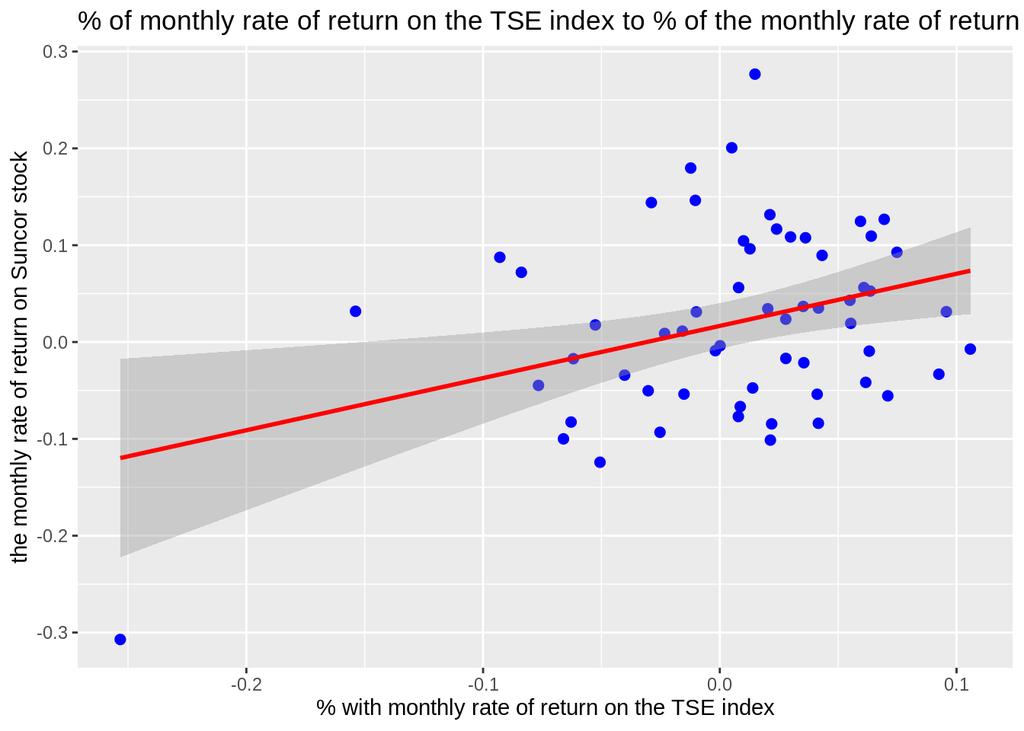

```r
ggplot(df7, aes(x = TSE.Index, y = Suncor)) + geom_point(col="blue", size = 2) + ylab("the monthly rate of return on Suncor stock") + xlab("% with monthly rate of return on the TSE index") + ggtitle("% of monthly rate of return on the TSE index to % of the monthly rate of return on Suncor stock") + geom_smooth(method="lm", col="red")
```

**b**

```r
predictdemovote = lm(Suncor ~ TSE.Index, data=df7)
options(scipen=999)
predictdemovote$coef
```

```
## (Intercept)   TSE.Index
##  0.01664794  0.53869099
```

The value of a and b are a=0.01664794 and b=0.53869099 From the training data, we have an estimate of the model:
$$R_{StockA,i} = 0.01664794 + 0.53869099 R_{Market, i} + e_{i}$$
**c** $\beta_{0}$ is the represents the risk-free interest rate. It means that when the monthly rate of return of the TSE Index is 0, the monthly rate of return for a common share of Suncor stock is 0.01664794. $\beta_{1}$ is the systematic risk. It measure’s the stocks volatility related to the market volatility. The slope of increase is 0.53869099.

**d**

```r
predict(predictdemovote, data.frame(TSE.Index=0.04))
```

```
##          1
## 0.03819558
```

**e** **Normality of residuals:**

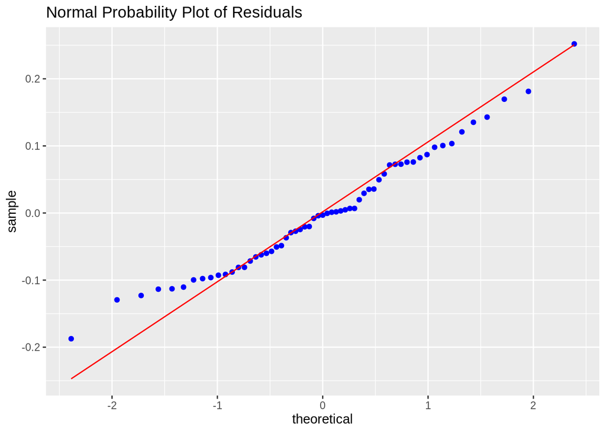

```r
predicted.values.demovote = predictdemovote$fitted.values #place the predicted values of y for each observed x into a vector
eisdemovote = predictdemovote$residuals      #pull out the residuals
diagnosticdf = data.frame(predicted.values.demovote, eisdemovote) #create a data frame of fitted.values and residuals
ggplot(diagnosticdf, aes(sample = eisdemovote)) +  stat_qq(col='blue') + stat_qqline(col='red') + ggtitle("Normal Probability Plot of Residuals")
```

the residuals are normally distributed

**Homoscedasticity:**

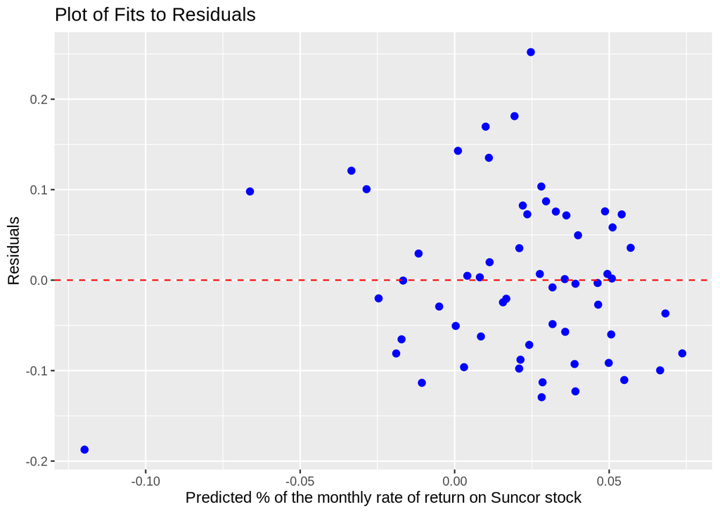

```r
ggplot(diagnosticdf, aes(x = predicted.values.demovote, y = eisdemovote)) +  geom_point(size=2, col='blue', position="jitter") + xlab("Predicted % of the monthly rate of return on Suncor stock") + ylab("Residuals") + ggtitle("Plot of Fits to Residuals") + geom_hline(yintercept=0, color="red", linetype="dashed")
```

homoscedasticity satisfied

**f**

```r
options(scipen=999)
coef(summary(predictdemovote))
```

```
##               Estimate Std. Error  t value    Pr(>|t|)
## (Intercept) 0.01664794 0.01177393 1.413966 0.162810655
## TSE.Index   0.53869099 0.19177963 2.808906 0.006797419
```

```r
Sb= 0.19177963
```

The statistical hypothesis to be tested is:
$${\rm H}_{0}: B(\beta_{1}) \leq 0 \:\: \text{( the monthly rate of return
of Suncor stock can not be expressed as a positive linear function of
the monthly rate of return of the TSE Index)} \\
{\rm H}_{A}: B(\beta_{1}) > 0 \:\: \text{( the monthly rate of return
of Suncor stock can be expressed as a positive linear function of the
monthly rate of return of the TSE Index)} \\$$
I set up the $\alpha = 0.05$ The value of the test statistic is

```r
Tobs = 0.53869099/ 0.19177963
Tobs
```

```
## [1] 2.808906
```

```r
1-pt(2.808906, 59-2)
```

```
## [1] 0.003398711
```

The $P$-value is
$$P-\text{value} = P(T_{59-2} > 2.808906) = 0.003398711$$
Because $p-value < \alpha$, Reject $H_{0}$. I conclude that the monthly rate of return of Suncor stock can be expressed as a positive linear function of the monthly rate of return of the TSE Index.

**g**

```r
confint(predictdemovote, conf.level=0.95)
```

```
##                    2.5 %     97.5 %
## (Intercept) -0.006928949 0.04022482
## TSE.Index    0.154658904 0.92272309
```

95% confidence interval for $\beta_{1}$ is from 0.154658904 to 0.92272309. As the monthly rate of return of the TSE Index increases by 1%, the monthly rate of return for a common share of Suncor stock will increase by an AVERAGE of anywhere between 0.154658904 to 0.92272309.

**h**

```r
predict(predictdemovote, newdata=data.frame(TSE.Index=0.03), interval="predict")
```

```
##          fit        lwr      upr
## 1 0.03280867 -0.1490657 0.214683
```

**i**

```r
predict(predictdemovote, newdata=data.frame(TSE.Index=0.0116), interval="predict")
```

```
##          fit        lwr       upr
## 1 0.02289675 -0.1587618 0.2045553
```

In a month of September, the TSE Index had a rate of return of 1.16%. With 95% confidence, compute the September rate of return for Suncor stock:

$$-0.1587618 \leq R_{x = 0.0116} \leq 0.2045553$$

**j**

```r
Nbootstraps = 1000 #resample n =  59, 1000 times
cor.boot = numeric(Nbootstraps)
nsize = dim(df7)[1]
for(i in 1:Nbootstraps)
{   #start of the loop
    index = sample(nsize, replace=TRUE)  #randomly picks a number between 1 and n, assigns as index
    demovote.boot = df7[index, ] #accesses the i-th row of the regressionex1.df data frame
    #
    cor.boot[i] = cor(~TSE.Index, ~Suncor, data=df7) #computes correlation for each bootstrap sample
    votedemocrat.lm = lm(Suncor ~ TSE.Index, data=df7)  #set up the linear model
}
#end the loop
#create a data frame that holds the results of teach of he Nbootstraps
bootstrapresultsdf = data.frame(cor.boot)
head(bootstrapresultsdf, 3)
```

```
##    cor.boot
## 1 0.3486972
## 2 0.3486972
## 3 0.3486972
```

```r
qdata(~cor.boot, c(0.025, 0.975), data=bootstrapresultsdf)
```

```
##      2.5%     97.5%
## 0.3486972 0.3486972
```

95% bootstrap confidence interavl for the value of the ρ, the population correlation that measures the degree of linear association between Suncor’s monthly rate of return and the TSE Index monthly rate of return is from 0.3486972 to 0.3486972.

##Q8 **a b c**

```r
gss = read.csv("http://people.ucalgary.ca/~jbstall/DataFiles/GSS2002.csv")
#gss
```

```r
conttablea1 <- tally(~SpendSci + GunLaw, data=gss) #if margin = TRUE, the chisq.test will count the row totals and column totals as other 'categories' for the row and column categorical variables
conttablea1
```

```
##              GunLaw
## SpendSci      Favor Oppose <NA>
##   About right   166     35  428
##   Too little    117     37  307
##   Too much       42     12  122
##   <NA>          412     95  992
```

The statistical hypothesis is

$$\begin{align}
{\rm H}_{0}: & \text{support for gun laws and the government
spending on Science are independent of each other} \\
{\rm H}_{A}: & \text{support for gun laws and the government
spending on Science are NOT independent of each other} \\
\end{align}$$
I set up the $\alpha = 0.05$

```r
chisq.test(conttablea1,simulate.p.value=TRUE)
```

```
##
##  Pearson's Chi-squared test with simulated p-value (based on 2000
##  replicates)
##
## data:  conttablea1
## X-squared = 4.1944, df = NA, p-value = 0.6642
```

```r
4.1944^2
```

```
## [1] 17.59299
```

from which

```r
1 - pchisq(17.59299, 6)
```

```
## [1] 0.007334053
```

**d**

```r
conttablea2 <- tally(~Race + Education , data=gss) #if margin = TRUE, the chisq.test will count the row totals and column totals as other 'categories' for the row and column categorical variables
conttablea2
```

```
##        Education
## Race    Bachelors Graduate   HS Jr Col Left HS <NA>
##   Black        27       15  231     34     101    2
##   Other        27       17   81     17      24    1
##   White       389      198 1173    151     275    2
```

The statistical hypothesis is

$$\begin{align}
{\rm H}_{0}: & \text{one’s level of Education is independent of
their Race} \\
{\rm H}_{A}: & \text{one’s level of Education is not independent of
their Race} \\
\end{align}$$
I set up the $\alpha = 0.05$

```r
chisq.test(conttablea2,simulate.p.value=TRUE)
```

```
##
##  Pearson's Chi-squared test with simulated p-value (based on 2000
##  replicates)
##
## data:  conttablea2
## X-squared = 83.575, df = NA, p-value = 0.0004998
```

```r
83.575^2
```

```
## [1] 6984.781
```

from which

```r
1 - pchisq(6984.781, 10)
```

```
## [1] 0
```

##Q9

```r
q9 = rbind(c(15,7,3,15), c(22, 7,3,11))  #create a table of observed counts called seatbelt

rownames(q9) = c("Fluvoxamine", "Placebo")
colnames(q9) = c("No Response", "Moderate Response","Marked Response","Remission")
q9
```

```
##             No Response Moderate Response Marked Response Remission
## Fluvoxamine          15                 7               3        15
## Placebo              22                 7               3        11
```

The statistical hypothesis is

$$\begin{align}
{\rm H}_{0}: & \text{there is not an association between the type of
treatment received and a patient’s response} \\
{\rm H}_{A}: & \text{there is an association between the type of
treatment received and a patient’s response} \\
\end{align}$$
I set up the $\alpha = 0.05$

```r
chisq.test(q9,simulate.p.value=TRUE)
```

```
##
##  Pearson's Chi-squared test with simulated p-value (based on 2000
##  replicates)
##
## data:  q9
## X-squared = 1.8337, df = NA, p-value = 0.6257
```

```r
1.8337^2
```

```
## [1] 3.362456
```

```r
1 - pchisq(3.362456, 3)
```

```
## [1] 0.3390441
```